# HOMEWORK 2 - Creating Value Through Data Mining (S402010)

Liam Phan

2022-10-30

# Quick Start

## Loading Packages

```r
library(data.table) # Efficient Dataframe
library(lubridate) # For Dates
library(tidyverse) # Multiple Package for Useful Data wrangling
library(esquisse) # Intuitive plotting
library(plyr) # Data splitting
library(dplyr)
library(ggplot2) # Plot Graphs
library(naniar) # for NA exploration in Dataframe
library(plotly) # Make ggplot2 Dynamic
library(DT) # Render Table in a explorable UI
library(gridExtra) # Multiple Plot at once
library(corrplot) # Correlation Plot
library(RColorBrewer) # For Color Palette
library(rmdformats) # Theme of HTML
library(manipulateWidget) # Handling multiple plotly graphs
library(flextable) # Show Table
library(class) # K-NN
```

> Those are required packages

# Exercise 1.

## 5.6 Evaluating Predictive Performance

### a.

> If the company beings working with a new set of 1000 leads to sell the same services, similar to the 500 in the plot study, witout any use of predictive modeling to target sales efforts, what is the estimated profit?

Without any predictive modeling, we can roughly estimated the profit with the following formula:

$$Sales_{Estimated} = 1000*\$2128 =
\$2128000$$

But the company will also have expenditures related to their sales, which would negatively impact the Total Profit. The sales effort would be:

$$Costs_{Estimated} = 1000*\$2500 =
\$2500000$$

Leading to negative Total Profit of…

$$TotalProfit_{Estimated} =
Sales_{Estimated} - Costs_{Estimated} \\ = \$2128000 - \$2500000 = -
\$372000$$

### b.

> If the firm wants the average profit on each sale to at least double the sales effort cost, and applies an appopriate cutoff with this predictive model to a new set of 1000 leads, how far down the new list of 1000 should it proceed (how many deciles)?

If we want to double the average profit on each sale, we should take the first decile (10%) on the Decile-wise lift chart which double the mean.

$$Ratio_{Estimated} =
\dfrac{2*\$2500}{\$2128} = 2.35$$

### c.

> Still considering the new list of 1000 leads, if the company applies this predictive model with a lower cutoff of $2500, how far should it proceed down the ranked leads, in terms of deciles?

We want the cutoff to be $2500:

$$Ratio_{Estimated} =
\dfrac{\$2500}{\$2128} = 1.17$$

If we take a look at the Decile-wise lift chart, we see that the 6th decile (approx mean-reponse of 1, same as 2128$)

### d.

> Why use this two-stage process for predicting sales–why not simply develop a model for predicting profit for the 1000 new leads?

# Exercise 2.

## 7.2 Personnal Loan Acceptance

### Loading Dataset and Basic Data Quality Check

Dimensions, Variables Count and Dataset Structure

| ID | Age | Experience | Income | ZIP Code | Family | CCAvg | Education | Mortgage | Personal Loan | Securities Account | CD Account | Online | CreditCard |
| --- | --- | --- | --- | --- | --- | --- | --- | --- | --- | --- | --- | --- | --- |
| 1 | 25 | 1 | 49 | 91,107 | 4 | 1.6 | 1 | 0 | 0 | 1 | 0 | 0 | 0 |
| 2 | 45 | 19 | 34 | 90,089 | 3 | 1.5 | 1 | 0 | 0 | 1 | 0 | 0 | 0 |
| 3 | 39 | 15 | 11 | 94,720 | 1 | 1.0 | 1 | 0 | 0 | 0 | 0 | 0 | 0 |
| 4 | 35 | 9 | 100 | 94,112 | 1 | 2.7 | 2 | 0 | 0 | 0 | 0 | 0 | 0 |
| 5 | 35 | 8 | 45 | 91,330 | 4 | 1.0 | 2 | 0 | 0 | 0 | 0 | 0 | 1 |
| 6 | 37 | 13 | 29 | 92,121 | 4 | 0.4 | 2 | 155 | 0 | 0 | 0 | 1 | 0 |

```
## [1] 5000   14
```

```
##                 ID                Age         Experience             Income
##               5000                 45                 47                162
##           ZIP Code             Family              CCAvg          Education
##                467                  4                108                  3
##           Mortgage      Personal Loan Securities Account         CD Account
##                347                  2                  2                  2
##             Online         CreditCard
##                  2                  2
```

```
## Classes 'data.table' and 'data.frame':   5000 obs. of  14 variables:
##  $ ID                : int  1 2 3 4 5 6 7 8 9 10 ...
##  $ Age               : int  25 45 39 35 35 37 53 50 35 34 ...
##  $ Experience        : int  1 19 15 9 8 13 27 24 10 9 ...
##  $ Income            : int  49 34 11 100 45 29 72 22 81 180 ...
##  $ ZIP Code          : int  91107 90089 94720 94112 91330 92121 91711 93943 90089 93023 ...
##  $ Family            : int  4 3 1 1 4 4 2 1 3 1 ...
##  $ CCAvg             : num  1.6 1.5 1 2.7 1 0.4 1.5 0.3 0.6 8.9 ...
##  $ Education         : int  1 1 1 2 2 2 2 3 2 3 ...
##  $ Mortgage          : int  0 0 0 0 0 155 0 0 104 0 ...
##  $ Personal Loan     : int  0 0 0 0 0 0 0 0 0 1 ...
##  $ Securities Account: int  1 1 0 0 0 0 0 0 0 0 ...
##  $ CD Account        : int  0 0 0 0 0 0 0 0 0 0 ...
##  $ Online            : int  0 0 0 0 0 1 1 0 1 0 ...
##  $ CreditCard        : int  0 0 0 0 1 0 0 1 0 0 ...
##  - attr(*, ".internal.selfref")=<externalptr>
```

Missing Variables Plot

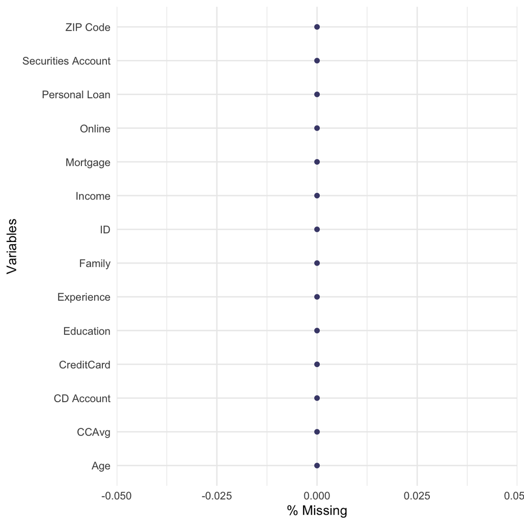

No Missing Values

### Partition The Data Into Training (60%) and Validation (40%) Sets

```r
# Setting Seed
set.seed(1)

# Splitting Training and Validation
sample <- sample(c(TRUE, FALSE), nrow(UniversalBank1), replace=TRUE, prob=c(0.6,0.4))
training  <- UniversalBank1[sample, ]
validation   <- UniversalBank1[!sample, ]

# Checking if proportions are right
train_prop <- dim(training)
validation_prop <- dim(validation)

train_prop_100 <- (train_prop[1]/nrow(UniversalBank1))*100
validation_prop_100 <- (validation_prop[1]/nrow(UniversalBank1))*100

paste(train_prop_100,"% In Training",validation_prop_100,"% In Validation")
```

```
## [1] "61 % In Training 39 % In Validation"
```

### a. Considering the following customer:

> Age = 40, Experience = 10, Income = 84, Family = 2, CCAvg = 2, Education_1 = 0, Education_2 = 1, Education_3 = 0, Mortgage = 0, Securities Account = 0, CD Account = 0, Online = 1, and Credit Card = 1.

Perform a Κ-NN Classification with all predictors except ID and ZIP code using Κ = 1

```r
# Setting Seed
set.seed(1)

# Removing Some Predictors
training <- training[,-c("ID","ZIP Code")]
validation <- validation[,-c("ID","ZIP Code")]

# Target Variable As Factor
training$`Personal Loan` <- as.factor(training$`Personal Loan`)
validation$`Personal Loan` <- as.factor(validation$`Personal Loan`)

# Education As Factor
training$Education <- as.factor(training$Education)
validation$Education <- as.factor(validation$Education)

# Education One-Hot Encoding
Education_As_Dummy_Training <- model.matrix(~0+training$Education)
Education_As_Dummy_Validation <- model.matrix(~0+validation$Education)

# Append to Training and Validation Sets
training <- cbind(training,Education_As_Dummy_Training)
training <- training[,-c("Education")]

validation <- cbind(validation,Education_As_Dummy_Validation)
validation <- validation[,-c("Education")]

# Renaming Education
training = training %>% rename( Education_1 = `training$Education1` , Education_2 = `training$Education2`, Education_3 = `training$Education3`)
validation = validation %>% rename( Education_1 = `validation$Education1` , Education_2 = `validation$Education2`, Education_3 = `validation$Education3`)

# Preprocess for Data Normalization
library(caret)

training_norm <- training
validation_norm <- validation

training_norm_s <- training[,-c("Personal Loan")]

norm_values <- preProcess(training_norm_s,method = c("center","scale"))

training_norm <- predict(norm_values,training)
validation_norm <- predict(norm_values,validation)

# KNN Model using class package
library(class)

# Data frame for a specific customer not in Data
Customer_Test <- data.frame("Age"=40,"Experience"=10,"Income"=84,"Family"=2,"CCAvg"=2,"Mortgage"=0,"Securities Account"=0,"CD Account"=0,"Online"=1,"CreditCard"=1,"Education_1"=0,"Education_2"=1,"Education_3"=0, check.names=FALSE)

# Preprocess the Customer New Data
Customer_Test_norm <- predict(norm_values, Customer_Test)

## KNN Training for Customer
predictions_customer <- knn(train=training_norm[,-c("Personal Loan")],test = Customer_Test_norm, cl = training_norm$`Personal Loan`, k=1)

predictions_customer <- as.factor(predictions_customer)

levels(predictions_customer) <- c("Fail","Success")

# Append Predictions to Customer not in Data
Customer_Test$Predicted <- predictions_customer

# Correct Factors of previous Validation
levels(Customer_Test$Predicted) <- c("Fail","Success")
```

```r
# Table Customer after Predictions
flextable(head(Customer_Test)) %>%
  fontsize(size = 7, part = "all")
```

| Age | Experience | Income | Family | CCAvg | Mortgage | Securities Account | CD Account | Online | CreditCard | Education_1 | Education_2 | Education_3 | Predicted |
| --- | --- | --- | --- | --- | --- | --- | --- | --- | --- | --- | --- | --- | --- |
| 40 | 10 | 84 | 2 | 2 | 0 | 0 | 0 | 1 | 1 | 0 | 1 | 0 | Fail |

> This Customer would be classified as not getting a Personnal Loan (Fail)

### b. What is the Choice of Κ that balances between overfitting and ignoring the predictor information?

```r
# Setting Seed
set.seed(1)

# Load Caret
library(caret)

# Number of iterations
max_iterations = 20

# Dataframe with 2 columns: k and accuracy
accuracy.df <- data.frame(k=seq(1,max_iterations,1),accuracy=rep(0,max_iterations))

# Compute K-NN for different k on validation
for(i in 1:max_iterations){
  # Testing K-NN
  knn.prediction <- knn(train = training_norm[,-c("Personal Loan")], test=validation_norm[,-c("Personal Loan")] , cl=training_norm$`Personal Loan`, k=i)
  # Storing into the accuracy.df results
  accuracy.df[i,2] <- confusionMatrix(knn.prediction, validation$`Personal Loan`)$overall[1]
}

# Table of Accuracy
flextable(accuracy.df) %>%
  fontsize(size = 12, part = "all")
```

| k | accuracy |
| --- | --- |
| 1 | 0.9676923 |
| 2 | 0.9574359 |
| 3 | 0.9641026 |
| 4 | 0.9574359 |
| 5 | 0.9564103 |
| 6 | 0.9533333 |
| 7 | 0.9538462 |
| 8 | 0.9507692 |
| 9 | 0.9507692 |
| 10 | 0.9476923 |
| 11 | 0.9487179 |
| 12 | 0.9471795 |
| 13 | 0.9466667 |
| 14 | 0.9451282 |
| 15 | 0.9456410 |
| 16 | 0.9446154 |
| 17 | 0.9425641 |
| 18 | 0.9415385 |
| 19 | 0.9415385 |
| 20 | 0.9425641 |

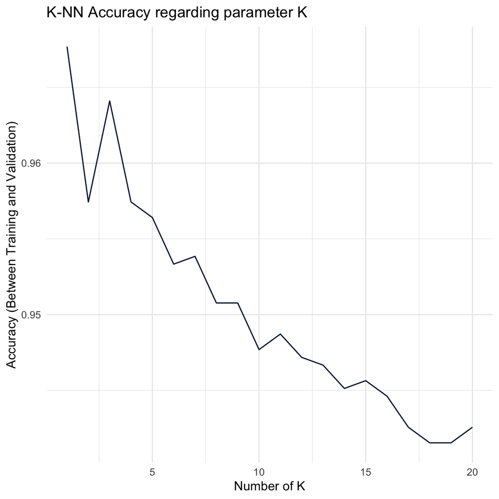

```r
# Ploting the K and accuracy together
ggplot(accuracy.df) +
 aes(x = k, y = accuracy) +
 geom_line(size = 0.5, colour = "#112446") +
 labs(x = "Number of K",
 y = "Accuracy (Between Training and Validation)", title = "K-NN Accuracy regarding parameter K") +
 theme_minimal()
```

```r
# Choosing Efficient K
highest_K <- which.max(accuracy.df$accuracy)

print(paste("Best K for Highest Accuracy is",highest_K))
```

```
## [1] "Best K for Highest Accuracy is 1"
```

### c. Show the confusion matrix for the validation data that results from using best Κ

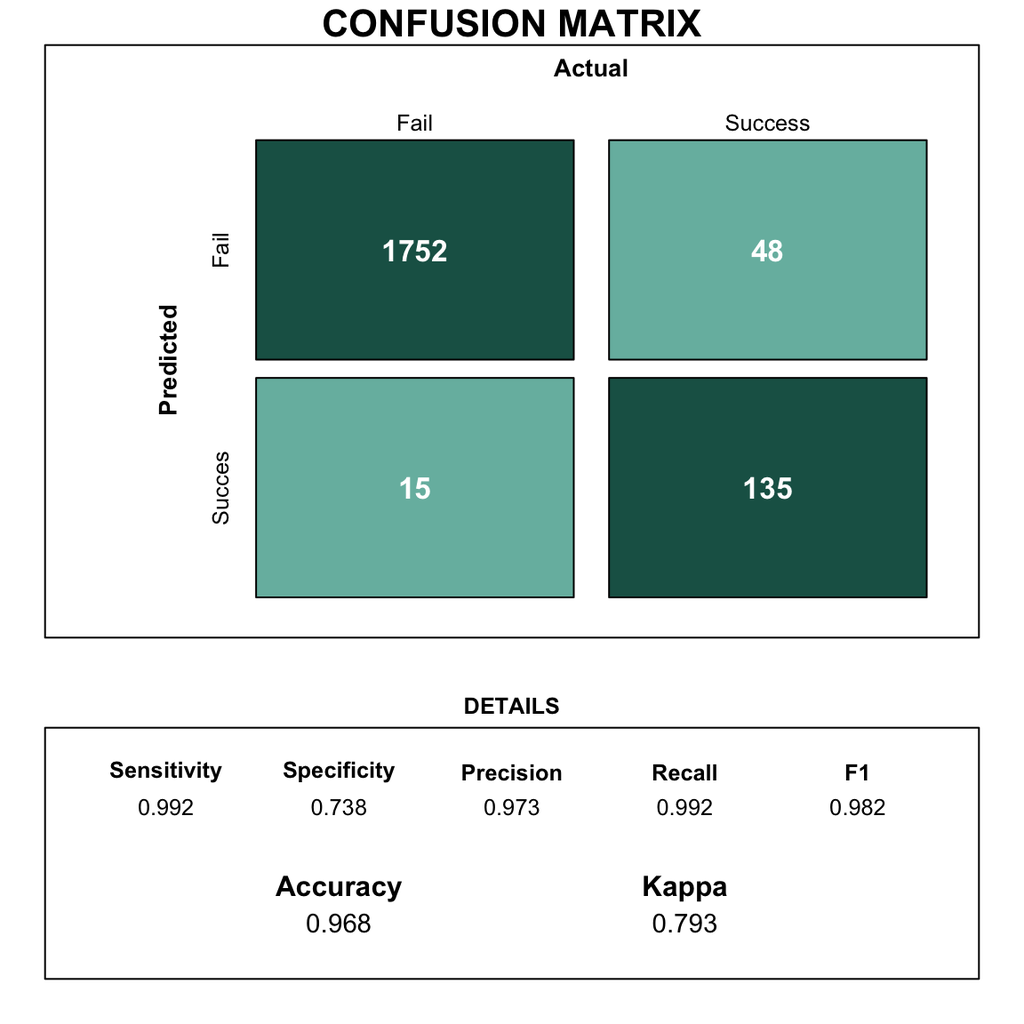

```r
# Setting Seed
set.seed(1)

# Computing Confusion Matrix with Best K
predictions_k <- knn(train=training_norm[,-c("Personal Loan")],test = validation_norm[,-c("Personal Loan")], cl = training_norm$`Personal Loan`, highest_K)

# As Factor Predictions
predictions_k <- as.factor(predictions_k)

# Relabel 0 and 1 to "Success" and "Fail
levels(predictions_k)<- c("Fail","Success")
levels(validation$`Personal Loan`) <- c("Fail","Success")

# Confusion Matrix
Confusion_Matrix_k <- confusionMatrix(data = predictions_k, reference = validation$`Personal Loan`)

# Plot
draw_confusion_matrix <- function(cm) {

  layout(matrix(c(1,1,2)))
  par(mar=c(2,2,2,2))
  plot(c(100, 345), c(300, 450), type = "n", xlab="", ylab="", xaxt='n', yaxt='n')
  title('CONFUSION MATRIX', cex.main=2)

  # create the matrix
  rect(150, 430, 240, 370, col='#1c6155')
  text(195, 435, 'Fail', cex=1.2)
  rect(250, 430, 340, 370, col='#77baae')
  text(295, 435, 'Success', cex=1.2)
  text(125, 370, 'Predicted', cex=1.3, srt=90, font=2)
  text(245, 450, 'Actual', cex=1.3, font=2)
  rect(150, 305, 240, 365, col='#77baae')
  rect(250, 305, 340, 365, col='#1c6155')
  text(140, 400, 'Fail', cex=1.2, srt=90)
  text(140, 335, 'Succes', cex=1.2, srt=90)

  # add in the cm results
  res <- as.numeric(cm$table)
  text(195, 400, res[1], cex=1.6, font=2, col='white')
  text(195, 335, res[2], cex=1.6, font=2, col='white')
  text(295, 400, res[3], cex=1.6, font=2, col='white')
  text(295, 335, res[4], cex=1.6, font=2, col='white')

  # add in the specifics
  plot(c(100, 0), c(100, 0), type = "n", xlab="", ylab="", main = "DETAILS", xaxt='n', yaxt='n')
  text(10, 85, names(cm$byClass[1]), cex=1.2, font=2)
  text(10, 70, round(as.numeric(cm$byClass[1]), 3), cex=1.2)
  text(30, 85, names(cm$byClass[2]), cex=1.2, font=2)
  text(30, 70, round(as.numeric(cm$byClass[2]), 3), cex=1.2)
  text(50, 85, names(cm$byClass[5]), cex=1.2, font=2)
  text(50, 70, round(as.numeric(cm$byClass[5]), 3), cex=1.2)
  text(70, 85, names(cm$byClass[6]), cex=1.2, font=2)
  text(70, 70, round(as.numeric(cm$byClass[6]), 3), cex=1.2)
  text(90, 85, names(cm$byClass[7]), cex=1.2, font=2)
  text(90, 70, round(as.numeric(cm$byClass[7]), 3), cex=1.2)

  # add in the accuracy information
  text(30, 35, names(cm$overall[1]), cex=1.5, font=2)
  text(30, 20, round(as.numeric(cm$overall[1]), 3), cex=1.4)
  text(70, 35, names(cm$overall[2]), cex=1.5, font=2)
  text(70, 20, round(as.numeric(cm$overall[2]), 3), cex=1.4)
}


#Plot the Confusion Matrix
draw_confusion_matrix(Confusion_Matrix_k)
```

### d. Consider the following customer:

> Age = 40, Experience = 10, Income = 84, Family = 2, CCAvg = 2, Education_1 = 0, Education_2 = 1, Education_3 = 0, Mortgage = 0, Securities Account = 0, CD Account = 0, Online = 1, and Credit Card = 1.

```r
# Setting Seed
set.seed(1)

# KNN Model on a specific customer not in Data
Customer_Test_2 <- data.frame("Age"=40,"Experience"=10,"Income"=84,"Family"=2,"CCAvg"=2,"Mortgage"=0,"Securities Account"=0,"CD Account"=0,"Online"=1,"CreditCard"=1,"Education_1"=0,"Education_2"=1,"Education_3"=0, check.names=FALSE)

# Preprocess the Customer New Data
Customer_Test_2_norm <- predict(norm_values, Customer_Test_2)

## KNN Training for Customer
predictions_customer_2 <- knn(train=training_norm[,-c("Personal Loan")],test = Customer_Test_2_norm, cl = training_norm$`Personal Loan`, k=highest_K)

predictions_customer_2 <- as.factor(predictions_customer_2)
levels(predictions_customer_2) <- c("Fail","Succes")

# Append Predictions to Customer not in Data
Customer_Test_2$Predicted <- predictions_customer_2
```

```r
# Table Customer after Predictions
flextable(head(Customer_Test_2)) %>%
  fontsize(size = 7, part = "all")
```

| Age | Experience | Income | Family | CCAvg | Mortgage | Securities Account | CD Account | Online | CreditCard | Education_1 | Education_2 | Education_3 | Predicted |
| --- | --- | --- | --- | --- | --- | --- | --- | --- | --- | --- | --- | --- | --- |
| 40 | 10 | 84 | 2 | 2 | 0 | 0 | 0 | 1 | 1 | 0 | 1 | 0 | Fail |

### e. Repartition the data (50%-30%-20%)

```r
# Setting Seed
set.seed(1)

# Splitting Training and Validation and Test
splitting <- sample(1:3,size=nrow(UniversalBank1),replace=TRUE,prob=c(0.5,0.3,0.2))
train <- UniversalBank1[splitting==1,]
valid <- UniversalBank1[splitting==2,]
test <- UniversalBank1[splitting==3,]

# Checking if proportions are right
Prop_train <- (nrow(train)/nrow(UniversalBank1))*100
Prop_valid <- (nrow(valid)/nrow(UniversalBank1))*100
Prop_test <- (nrow(test)/nrow(UniversalBank1))*100

# Print Proportion
paste(Prop_train,"% In Training",Prop_valid,"% In Validation",Prop_test,"% In Test")
```

```
## [1] "51.28 % In Training 27.74 % In Validation 20.98 % In Test"
```

```r
# Setting Seed
set.seed(1)

# Removing Some Predictors
train <- train[,-c("ID","ZIP Code")]
valid <- valid[,-c("ID","ZIP Code")]
test <- test[,-c("ID","ZIP Code")]

# Target Variable As Factor
train$`Personal Loan` <- as.factor(train$`Personal Loan`)
valid$`Personal Loan` <- as.factor(valid$`Personal Loan`)
test$`Personal Loan` <- as.factor(test$`Personal Loan`)

# Education As Factor
train$Education <- as.factor(train$Education)
valid$Education <- as.factor(valid$Education)
test$Education <- as.factor(test$Education)

# Education One-Hot Encoding
Education_As_Dummy_Train <- model.matrix(~0+train$Education)
Education_As_Dummy_Valid <- model.matrix(~0+valid$Education)
Education_As_Dummy_Test <- model.matrix(~0+test$Education)

# Append to Training and Validation Sets
train <- cbind(train,Education_As_Dummy_Train)
train <- train[,-c("Education")]

valid <- cbind(valid,Education_As_Dummy_Valid)
valid <- valid[,-c("Education")]

test <- cbind(test,Education_As_Dummy_Test)
test <- test[,-c("Education")]

# Renaming Education
train = train %>% rename( Education_1 = `train$Education1` , Education_2 = `train$Education2`, Education_3 = `train$Education3`)
valid = valid %>% rename( Education_1 = `valid$Education1` , Education_2 = `valid$Education2`, Education_3 = `valid$Education3`)
test = test %>% rename( Education_1 = `test$Education1` , Education_2 = `test$Education2`, Education_3 = `test$Education3`)

# Preprocess for Data Normalization
library(caret)

train_norm <- train
validn_norm <- valid
test_norm <- test

train_norm_s <- train[,-c("Personal Loan")]

norm_values_2 <- preProcess(train_norm_s,method = c("center","scale"))

train_norm <- predict(norm_values_2,train)
valid_norm <- predict(norm_values_2,valid)
test_norm <- predict(norm_values_2,test)
```

> Confusion Matrix for Train VS Valid

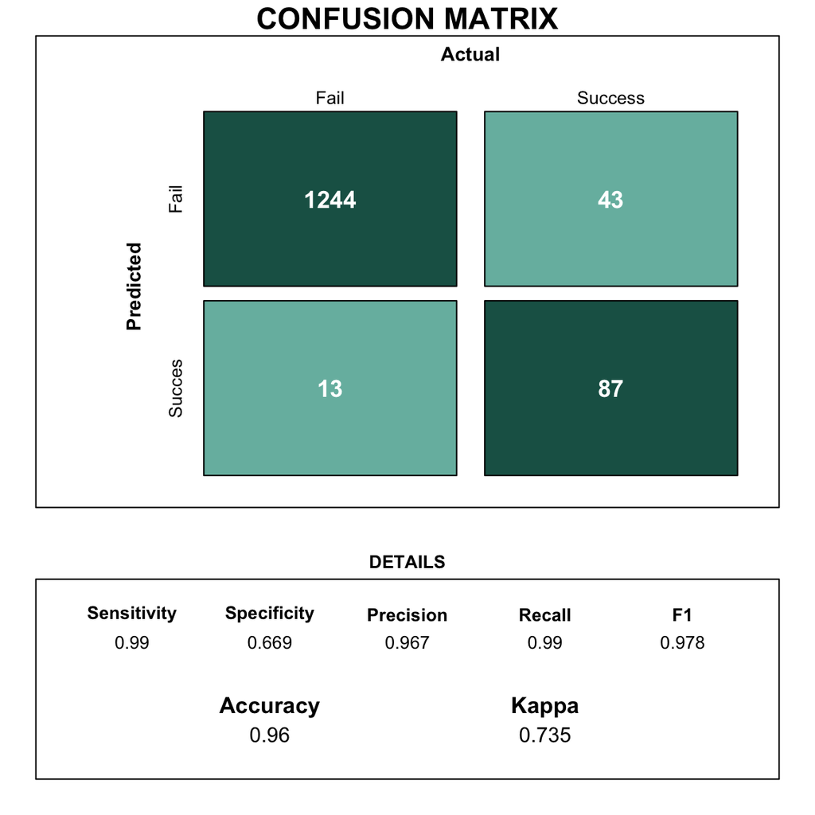

```r
# Train VS Valid

# Setting Seed
set.seed(1)

# Computing Confusion Matrix with Best K
predictions_k_new <- knn(train=train_norm[,-c("Personal Loan")],test = valid_norm[,-c("Personal Loan")], cl = train_norm$`Personal Loan`, highest_K)

# As Factor Predictions
predictions_k_new <- as.factor(predictions_k_new)

# Relabel 0 and 1 to "Success" and "Fail
levels(predictions_k_new)<- c("Fail","Success")
levels(valid$`Personal Loan`) <- c("Fail","Success")

# Confusion Matrix
Confusion_Matrix_k_New <- confusionMatrix(data = predictions_k_new, reference = valid$`Personal Loan`)

#Plot the Confusion Matrix
draw_confusion_matrix(Confusion_Matrix_k_New)
```

> Confusion Matrix for Train VS Test

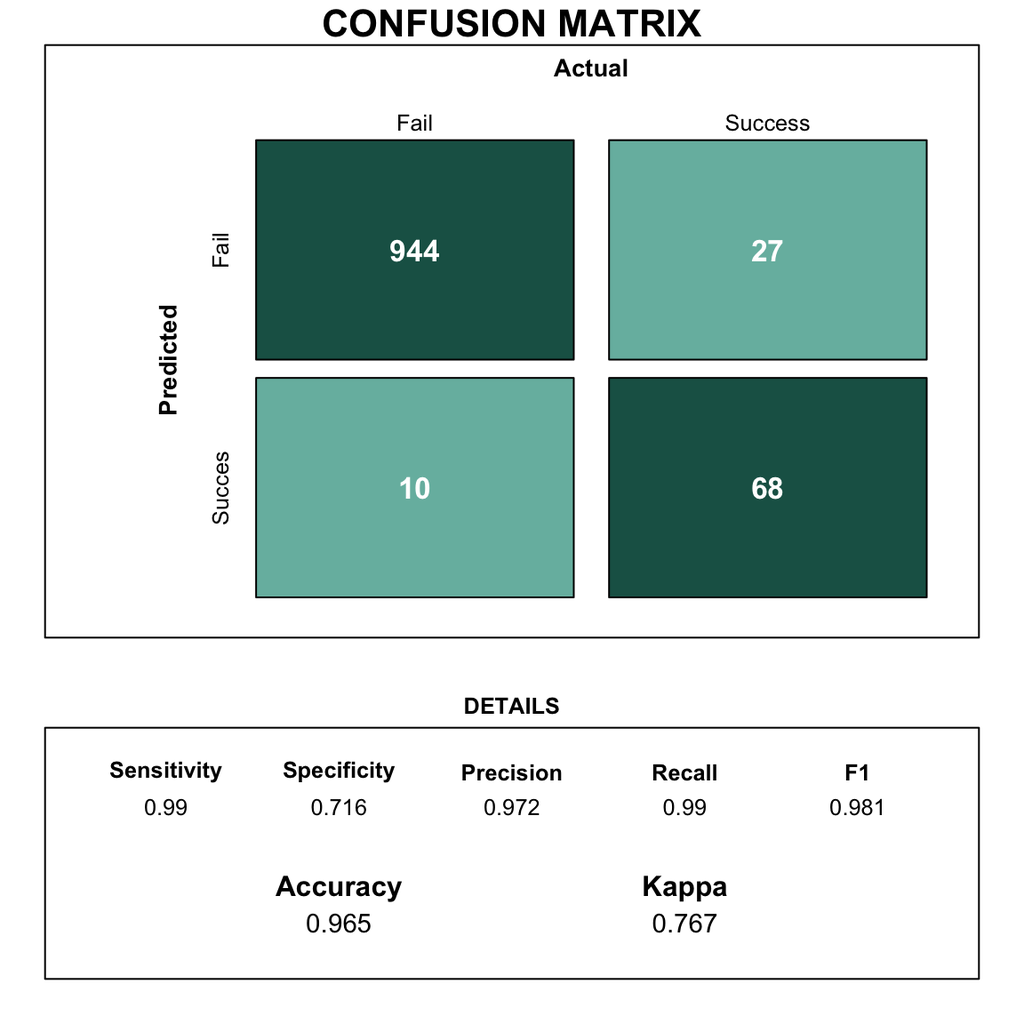

```r
# Train VS Test

# Setting Seed
set.seed(1)

# Computing Confusion Matrix with Best K
predictions_k_new2 <- knn(train=train_norm[,-c("Personal Loan")],test = test_norm[,-c("Personal Loan")], cl = train_norm$`Personal Loan`, highest_K)

# As Factor Predictions
predictions_k_new2 <- as.factor(predictions_k_new2)

# Relabel 0 and 1 to "Success" and "Fail
levels(predictions_k_new2)<- c("Fail","Success")
levels(test$`Personal Loan`) <- c("Fail","Success")

# Confusion Matrix
Confusion_Matrix_k_New2 <- confusionMatrix(data = predictions_k_new2, reference = test$`Personal Loan`)

#Plot the Confusion Matrix
draw_confusion_matrix(Confusion_Matrix_k_New2)
```

# Exercise 3.

## 8.1 Personal Loan Acceptance

### Partition the data into training (60%) and validation (40%) sets

```r
UniversalBank2 <- fread("DATA/UniversalBank.csv")

# Setting Seed
set.seed(1)

# Splitting Training and Validation
sample2 <- sample(c(TRUE, FALSE), nrow(UniversalBank2), replace=TRUE, prob=c(0.6,0.4))
training_8  <- UniversalBank2[sample2, ]
validation_8   <- UniversalBank2[!sample2, ]

# Checking if proportions are right
training_8_prop <- (nrow(training_8)/nrow(UniversalBank2))*100
validation_8_prop <- (nrow(validation_8)/nrow(UniversalBank2))*100

paste(training_8_prop,"% In Training",validation_8_prop,"% In Validation")
```

```
## [1] "61 % In Training 39 % In Validation"
```

### a) Pivot Table

```r
library(pivottabler)

# Duplicata of Training Data for Pivot Data
pivot_data <- training_8

# As Factor
pivot_data$Online <- factor(pivot_data$Online,levels = c(0,1),labels=c("Inactive Online","Active Online"))
pivot_data$CreditCard <- factor(pivot_data$CreditCard,levels = c(0,1),labels=c("No Credit Card","Credit Card"))
pivot_data$`Personal Loan` <- factor(pivot_data$`Personal Loan`,levels = c(0,1),labels=c("No Personal Loan","Personal Loan"))

# Pivot Table
pt <- PivotTable$new()
pt$addData(pivot_data)
pt$addColumnDataGroups("Online")
pt$addRowDataGroups("CreditCard")
pt$addRowDataGroups("Personal Loan")
pt$defineCalculation(calculationName="Total", summariseExpression="n()")
pt$renderPivot()
```

[interactive chart not shown]

### b) Probability of a Customer who owns a bank credit card and is actively using online banking services would accept the loan offer?

> Using Bayes Theorem

$$\small P(Loan=1 | CC=1 \cap Online=1) =
\\ \small \dfrac{54}{506+54} =\dfrac{54}{560} = 0.09642857 = 9.64
\%$$

> Thus, there is 9.64% probability that this kind of customer would accept the loan offer.

### c) Pivot Table in 2 Versions

```r
library(pivottabler)

# Pivot Table 1
pt1 <- PivotTable$new()
pt1$addData(pivot_data)
pt1$addColumnDataGroups("Online")
pt1$addRowDataGroups("Personal Loan")
pt1$defineCalculation(calculationName="Total", summariseExpression="n()")
pt1$renderPivot()
```

[interactive chart not shown]

```r
# Pivot Table 1
pt2 <- PivotTable$new()
pt2$addData(pivot_data)
pt2$addColumnDataGroups("CreditCard")
pt2$addRowDataGroups("Personal Loan")
pt2$defineCalculation(calculationName="Total", summariseExpression="n()")
pt2$renderPivot()
```

[interactive chart not shown]

### d) Compute the following quantities

#### i.

$$\small P (CC=1 | Loan=1) = \\ \small
\dfrac{95}{297} = 0.3198653 = 31.99 \%$$

#### ii.

$$\small P (Online=1 | Loan=1) =\\
\small \dfrac{188}{297}= 0.6329966 = 63.30 \%$$

#### iii.

$$\small P (Loan=1) = \dfrac{297}{3050} =
0.09737705 = 9.74 \%$$

#### iv.

$$\small P (CC=1 | Loan=0) = \\ \small
\dfrac{827}{2753} = 0.3003996 = 30.04 \%$$

#### v.

$$\small P (Online=1 | Loan=0) = \\ \small
\dfrac{1626}{2753} = 0.5906284 = 59.06 \%$$

#### vi.

$$\small P (Loan=0) = \dfrac{2753}{3050} =
0.902623 = 90.26\%$$

### e) Compute naive Bayes Probability

$$\small P(Loan=1|CC=1,Online=1)$$
Using the naive Bayes Probability give us the following computation:

$$\small P(Loan=1|CC=1,Online=1) = \\
\small
\dfrac{P(Loan=1)*P(CC=1|Loan=1)*P(Online=1|Loan=1)}{P(CC=1)*P(Online=1)}=\\
\small \dfrac{0.09737705*0.3198653*0.6329966}{0.3022951*0.5947541} =
0.1096621 = 10.97\%$$

### f) Accurate Estimate

> The Naive approach give us 10.97%, while the Exact Bayes probability give us 9.64%

### g) Run Model and Comparisons

$$P(Loan=1|CC=1,Online=1)$$

```r
library(naivebayes)

# As factor for Loan
training_8$Online <- factor(training_8$Online,levels = c(0,1),labels=c("Inactive Online","Active Online"))
training_8$CreditCard <- factor(training_8$CreditCard,levels = c(0,1),labels=c("No Credit Card","Credit Card"))
training_8$`Personal Loan` <- factor(training_8$`Personal Loan`,levels = c(0,1),labels=c("No Personal Loan","Personal Loan"))

Naivebayes <-  naive_bayes(training_8$`Personal Loan` ~ training_8$CreditCard + training_8$Online, data=training_8)

summary(Naivebayes)
```

```
##
## ================================== Naive Bayes ==================================
##
## - Call: naive_bayes.formula(formula = training_8$`Personal Loan` ~ training_8$CreditCard +      training_8$Online, data = training_8)
## - Laplace: 0
## - Classes: 2
## - Samples: 3050
## - Features: 2
## - Conditional distributions:
##     - Bernoulli: 2
## - Prior probabilities:
##     - No Personal Loan: 0.9026
##     - Personal Loan: 0.0974
##
## ---------------------------------------------------------------------------------
```

```r
Naivebayes
```

```
##
## ================================== Naive Bayes ==================================
##
##  Call:
## naive_bayes.formula(formula = training_8$`Personal Loan` ~ training_8$CreditCard +
##     training_8$Online, data = training_8)
##
## ---------------------------------------------------------------------------------
##
## Laplace smoothing: 0
##
## ---------------------------------------------------------------------------------
##
##  A priori probabilities:
##
## No Personal Loan    Personal Loan
##       0.90262295       0.09737705
##
## ---------------------------------------------------------------------------------
##
##  Tables:
##
## ---------------------------------------------------------------------------------
##  ::: training_8$CreditCard (Bernoulli)
## ---------------------------------------------------------------------------------
##
## training_8$CreditCard No Personal Loan Personal Loan
##        No Credit Card        0.6996004     0.6801347
##        Credit Card           0.3003996     0.3198653
##
## ---------------------------------------------------------------------------------
##  ::: training_8$Online (Bernoulli)
## ---------------------------------------------------------------------------------
##
## training_8$Online No Personal Loan Personal Loan
##   Inactive Online        0.4093716     0.3670034
##   Active Online          0.5906284     0.6329966
##
## ---------------------------------------------------------------------------------
```

$$\small P(Loan=1|CC=1,Online=1) = \\
\small
\dfrac{P(Loan=1)*P(CC=1|Loan=1)*P(Online=1|Loan=1)}{P(CC=1)*P(Online=1)}=\\
\small \dfrac{0.09737705*0.3198653*0.6329966}{0.3022951*0.5947541} =
0.1096621 = 10.97\%$$

# References

[Github Repo for this Homework 2](https://github.com/LiamPhan17/DATA_MINING_HW2)

[Data Mining for Business Analytics: Concepts, Techniques, and Applications in R](https://www.wiley.com/en-us/Data+Mining+for+Business+Analytics:+Concepts,+Techniques,+and+Applications+in+R-p-9781118879368)

[How to Split Data into Training & Test Sets in R (3 Methods)](https://www.statology.org/train-test-split-r/)